# Exploring the Robustness of Linear Regression

Juan Antonio Montero de Espinosa Reina

5/31/2020

# Linear Regression and p-values

- Statistical models are useful to understand relationships between variables.
- Due to its simplicity, one of the most popular such models is Linear Regression
  - For example, we may want to see how much GDP per capita (x) affects Life Expectancy (y) on average
  - Implicitly, Linear Regression assumes the model $y = \alpha + \beta x + u$ (where $u$ is the error term)
- Researchers use p-values on the estimated $\beta$ to try to answer the following question: does variable x have an effect on variable y on average?
- The lower the p-value , the more likely we are to accept that variable x has a linear effect on y. Commonly used thresholds to accept a linear relationship between variables are 0.1 (arguably), 0.05 and 0.01
- This App lets you explore the robustness of the p-value statistic to changes in many parameters of the relationship between two variables.

# The Underlying Model

- Internally, the App simulates the following model:
  $$y = \alpha + \beta f(x) + u$$
  where $\alpha$ and $\beta$ are constants (called intercept and slope, respectively). $u$ is assumed to be normal with zero mean. Finally, $f$ is any univariate function (by default, $f(x) = x$)
- In the App, you can play around with the specifications of the simple model above! You can change $f$, the number of observations in the sample, and many more things, and instantly check the p-value of the slope!
- What is even cooler, you can add points to the relationship by clicking on the plot!

# Running the App

- The entire project sits on my Github account “JMonteroEspinosa”, repo “LinearModelRobustness”. Commits are welcome! :)
- To run the App within R or RStudio, you can simply run (with shiny installed):

```r
library(shiny)
runGitHub("LinearModelRobustness", "JMonteroEspinosa", subdir = "app")
```

- Currently, the model is also hosted at https://jmontero.shinyapps.io/LinearModelRobustness/
- In the current implementation, the graph takes a bit more time to load, so be patient
- Let’s see a screenshot to clarify p-values

# Example of No Linear Relationship

- From the default options, I simply change the slope to be 0. This implies that x and y will be unrelated!

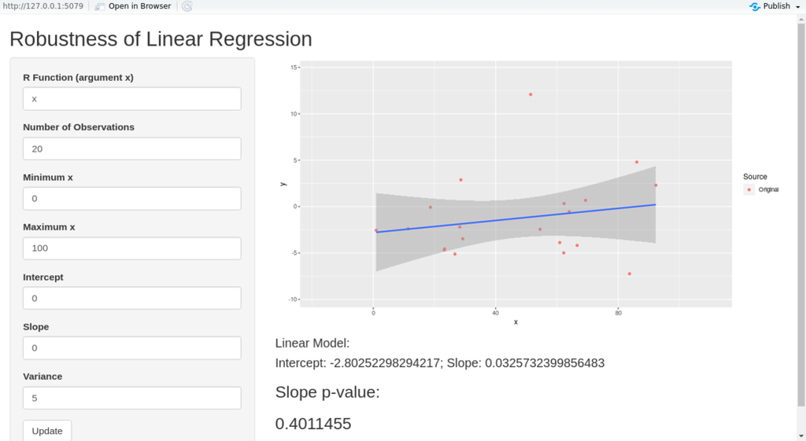

- We see that the p-value is 0.40, which in practice means we would discard any relationship. Good!
- But what if you add a point in some of the corners? (Be careful about outliers in your analysis!)
- And what if you write $sin(x)$ as the function (with slope different from zero)? does the model find any relationship?
- These are just some of the questions that you can answer with this small but cool app!